# Final project

**Evaluation of Zika virus research collaboration**

**Mateo Reveiz**

This analysis is part of an assignment for CMSC320, Introductionto Data Science, at the University of Maryland, College Park.

Zika is an infectious disease caused by the Zika virus. The virus is mostly transmitted through the Aedes species mosquito (Ae. aegypti and Ae. albopictus). It can also be transmitted through a pregnant woman to a fetus and through sexual activity.

Although Zika's mortality rate is fairly low, and most people might not even realize they have Zika, it is still dangerous for pregnant women and a developing fetus. Indeed, Zika infection during pregnancy can cause birth defects of the brain (microcephaly). Additionally, there have been increased reports of Guillain-Barré syndrome in areas affected by Zika.

More information about Zika can be found in the [CDC website](https://www.cdc.gov/zika/index.html), as well as the [Pan American Health Organization](https://www.paho.org/hq/index.php?option=com_topics&view=article&id=427&Itemid=41484&lang=enPan) (Paho).

In 2016, the WHO declared the Zika virus outbreak an international public health emergency. The poorly researched topic suddenly became a focal investigation point among many countries. The global response to this outbreak and the collaboration that emerged between countries is essential to understand regional interactions that could be reinforced for future outbreaks.

This analysis will try to investigate the collaboration between countries from two main sources. First, we will focus on the reported affiliation from the authors of each article. Once country affiliations are identified and analysed, we will focus on the actual content of the articles by analyzing the abstracts. The goal of this second analysis is to identify key reseach areas and how countries might speciliaze or prioritize certain areas above others.

We will start by including some libraries for our analysis

```python
# Data structures, math
from collections import defaultdict
import numpy as np
import pandas as pd
import csv

# Build networks
import networkx as nx

# Parse XML data
from xml.dom.minidom import parse
import xml.dom.minidom

# Handle time
from datetime import datetime
from datetime import timedelta

# NLP stuff
import re
import nltk
import string
from sklearn.feature_extraction.text import TfidfVectorizer
from nltk.stem.snowball import SnowballStemmer
from geotext import GeoText

# Plotting
import matplotlib.pyplot as plt
import seaborn as sns
from pandas.plotting import register_matplotlib_converters
register_matplotlib_converters()

# ML
from sklearn.cluster import KMeans
from sklearn.metrics.pairwise import cosine_similarity
```

**Data collection**

The first step in our analysis is extracting information. As we will focus on country collaboration, it will be useful to get some data on countries in general, such as the continent. Although this analysis does not take into consideration the language of the country, it would be interesting to also add that variable in the future.

All the information was downloaded from http://www.geonames.org/ and saved as a text file.

```python
# Get country information
df_countries = pd.DataFrame(columns = ["Code", "Country", "Population", "Continent"])

with open('country_info_2.txt') as f:
    lines = f.readlines()
    for i,line in enumerate(lines):
        data = line.strip().split("\t")
        df_countries.loc[data[1]] = data

f.close()

# Keep track of total country article occurences (if two american authors in article, then US counted twice)
df_countries["total_occur"] = 0
# Keep track of unique country article occurences (if two american authors in article, then US counted only once)
df_countries["uniq_occur"] = 0
```

The results of this table will be displayed and explained at the **Data collection results** section below.

Now that we have some information on countries, we can download the main dataset. We can extract the Zika data from XML files downloaded from PubMed.

https://www.ncbi.nlm.nih.gov/pubmed

A simple (manual search) was done with the following query:

"zika virus"[MeSH Terms] OR ("zika"[All Fields] AND "virus"[All Fields]) OR "zika virus"[All Fields] OR "zika"[All Fields] OR "zika virus infection"[MeSH Terms] OR ("zika"[All Fields] AND "virus"[All Fields] AND "infection"[All Fields]) OR "zika virus infection"[All Fields]

We first parse the XML to get individual articles

```python
DOMTree = xml.dom.minidom.parse("pubmed_result.xml")
collection = DOMTree.documentElement
articles = collection.getElementsByTagName("PubmedArticle")
```

We define 3 tables to store the information. The description of the tables is done in the **Data collection results** section below.

```python
df_articles = pd.DataFrame(columns = ["articleID", "title", "date", "abstract", "all_keywords"])
df_article_countries = pd.DataFrame(columns = ["articleID", "country", "country_mentions", "continent"])
df_article_keywords = pd.DataFrame(columns=["articleID", "keyword"])
```

Before we actually parse the XML data, we will define multiple helper functions

First we have a function that recursively extracts the text from a given XML node.

```python
# https://stackoverflow.com/questions/4485132/python-how-do-you-get-an-xml-elements-text-content-using-xml-dom-minidom
# mike rodent, answered May 16 '15 at 12:02
# Recursively get all text from a node
def get_all_text(node):
        if node.nodeType ==  node.TEXT_NODE:
            return node.data.strip()
        else:
            text_string = " "
            for child_node in node.childNodes:
                text_string += get_all_text(child_node)
            return text_string.strip()
```

For certain affiliations, we need to handle specific cases that are not detected well by the GeoText module imported. Although this list is very short, it can be expanded in the future to ensure more accurate geographical data.

```python
# Sometimes some countries, states, cities of particular importance have to be handled as special cases
# For this assignment, this list is very limited. However, over time, this should be refined
def handle_special_case(countries):
    for country in countries:
        if country == "Georgia":
            return True, "United States"
    return False, ""
```

Affiliations can have this form:

"Centro de Estudios Parasitológicos y de Vectores (CEPAVE-CONICET), Universidad Nacional de La Plata, La Plata, Buenos Aires, Argentina."

From this, the country "Argentina" is detected as well as the cities La Plata and Buenos Aires. Those two cities appear in two countries, Colombia and Argentina. A higher weight is given to direct country mentions although city mentions do have some weight. At the end, this affiliation is classified as Argentina. ['Argentina'] [('Argentina', 2), ('Colombia', 2)] -> Argentina

The results from this program use the geotext module for country detection and give decent results. However, it is necessary to improve the accuracy of the program to avoid country misclassifications.

```python
# countries: list of strings ['United States']
# countries_mentions list of tuples [('United States', 2), ('Australia', 1)]
# Given this, we need to make the best guess as to what the country really is
# This is a helper method for get_affiliations() below
def country_decider(countries, countries_mentions):
    ret = defaultdict(int)

    # If no affiliations detected, return nan
    if len(countries) == 0 and countries_mentions == 0:
        return np.nan

    # If special case, return
    flag, final_country = handle_special_case(countries)
    if flag:
        return final_country

    for country in countries:
        ret[country] += 2 # give higher weight to country label

    for country, mentions in countries_mentions:
        ret[country] += mentions

    max_m = 0
    final_country = np.nan
    for k,v in ret.items():
        if v > max_m:
            max_m = v
            final_country = k

    return final_country
```

Getting the abstract is pretty straightforward:

```python
# Extracts an article's abstract
def get_abstract(article):
    abstract_nodes = article.getElementsByTagName("Abstract")
    abstract = " ".join(get_all_text(t) for t in abstract_nodes)
    return abstract
```

Dates are converted from strings to datetime objects. When no date is found, a hot-deck imputation method is used as the articles were downloaded in chronological order. It is worth noting that the publication date that we extract differs from the actual moment an article is written, sent for approval, or approved. Therefore, we might see some articles whose dates are in the "future" or 2020.

```python
# Extracts an article's date, converts it to datetime object
def get_date(article, last_date):
    date_node = article.getElementsByTagName("PubMedPubDate")

    # Hot-deck imputation if date is missing
    date = last_date

    # Not all articles might have date
    if len(date_node) > 0:
        year_node = date_node[0].getElementsByTagName("Year")
        month_node = date_node[0].getElementsByTagName("Month")
        day_node = date_node[0].getElementsByTagName("Day")

        # Sometimes the day or month might be missing
        if len(year_node) > 0 and len(month_node) > 0 and len(day_node) > 0:
            dateY = year_node[0].childNodes[0].data
            dateM = month_node[0].childNodes[0].data
            dateD = day_node[0].childNodes[0].data
            date = datetime.strptime("{}/{}/{}".format(dateY, dateM, dateD), "%Y/%m/%d")
            last_date = date


    return date, last_date
```

Getting the title is pretty straightforward as well. Although we will not use this information for the moment in the analysis, it is certainly useful to keep for future updates of this code.

```python
# Extracts an article's title
def get_title(article):
    # Extract article title. When <i>title</i> or <sup>title</sup> are used, we need to enter the child and concatenate
    # by recursively extracting text from nodes
    title_node = article.getElementsByTagName("ArticleTitle")[0].childNodes
    title = " ".join(get_all_text(t) for t in title_node)
    return title
```

This is the main affiliation getter, which calls other helper methods above.

```python
def get_affiliations(article):
    affil_node = article.getElementsByTagName("Affiliation")
    # Each article has multiple authors, multiple affiliations
    article_affiliations = defaultdict(int)
    for affil in affil_node:
        # Get text
        affil_text = affil.firstChild.data

        # Find mentions from cities, countries etc..
        cities = GeoText(affil_text).cities
        countries_mentions = GeoText(affil_text).country_mentions
        countries = GeoText(affil_text).countries

        # Handle special cases not detected
        my_regex = r"\bUK\b"
        if re.search(my_regex, affil_text, flags=re.IGNORECASE):
            countries.append("United Kingdom")
            countries.append("United Kingdom")

        # countries_mentions gives country code and mention name as a dictionary
        # extract key/value pair and transorm code to full country name
        countries_mentions  = [(df_countries.loc[df_countries["Code"] == k]["Country"].values[0],v) for k,v in countries_mentions.items()]

        # Get majority vote on country
        final_country = country_decider(countries, countries_mentions)

        # Add mentions to overall article unless nan
        if not pd.isnull(final_country):
            article_affiliations[final_country] += 1
            # Add mentions to table
            df_countries.loc[final_country, "total_occur"] += 1


    if len(article_affiliations) == 0:
        article_affiliations = np.nan
    else:
        for k,v in article_affiliations.items():
            df_countries.loc[k, "uniq_occur"] += 1

    return article_affiliations
```

The last helper method is the keyword getter. We are done with helper methods!

```python
# Extract keywords
def get_keywords(article):
    keyword_nodes = article.getElementsByTagName("Keyword")
    keywords = []
    [keywords.append(get_all_text(t).lower()) for t in keyword_nodes]

    return keywords
```

After defining all those helper methods, we can finally go through the data and parse the information. For each article, we extract titles, dates, keywords, abstracts and affiliations and save them to the corresponding tables.

```python
# Hot deck imputation if the date is missing. (Pubmed articles were downloaded by chronologcal sorting)
last_date = 0
offset = 0

no_affil_count = 0
no_keyword_count = 0

for i, article in enumerate(articles):

    # Extract title
    title = get_title(article)

    # Extract date
    date, last_date = get_date(article, last_date)

    # Extract abstract
    abstract = get_abstract(article)

    # Extract affiliations
    affiliations = get_affiliations(article)

    # Extract keywords
    keywords = get_keywords(article)

    # Skip if no affiliations
    if pd.isnull(affiliations):
        offset = offset + 1
        no_affil_count = no_affil_count + 1
        continue

    # Add to articles table
    df_articles.at[i-offset, "articleID"] = i - offset   # This should continous numbering, if skipped have to handle later TODO
    df_articles.at[i-offset, "title"] = title
    df_articles.at[i-offset, "date"] = date
    df_articles.at[i-offset, "abstract"] = abstract

    # Add to article article_countries table
    for country,mentions in affiliations.items():
        continent=df_countries.loc[df_countries["Country"]==country]["Continent"].values[0]
        df_article_countries.loc[len(df_article_countries)]=[i-offset, country, mentions, continent]

    #Add to article_keywords table
    if len(keywords) == 0:
        no_keyword_count = no_keyword_count + 1
        df_article_keywords.loc[len(df_article_keywords)]=[i-offset, np.nan]
        df_articles.at[i-offset, "all_keywords"] = ""
    else:
        all_keywords = " ".join(keywords)
        df_articles.at[i-offset, "all_keywords"] = all_keywords
        for keyword in keywords:
            df_article_keywords.loc[len(df_article_keywords)]=[i-offset, keyword.lower().replace("é", "e")]
```

**Data collection results**

**df_articles**: This table contains information about indiviual articles. Each article has a unique ID, a title, a date, an abstract and all keywords. The tidy keywords will be stored in another table. This table is related to other tables by the articleID. More columns and variables will be added over time.

```python
df_articles.head(5)
```

|  | articleID | title | date | abstract | all_keywords |
| --- | --- | --- | --- | --- | --- |
| 0 | 0 | Generation of Zika virus-specific T cells from... | 2019-04-11 00:00:00 | Zika virus (ZIKV) infection can cause severe b... | good manufacturing practice t lymphocytes zika... |
| 1 | 1 | Vertical Transmission of Zika Virus (Flaviviri... | 2018-12-10 00:00:00 | Zika virus (ZIKV) has emerged as a globally im... | aedes aegypti zika virus fitness cost vertical... |
| 2 | 2 | Utility of reference materials for Zika Virus ... | 2018-12-19 00:00:00 | The emergence of Zika virus (ZIKV) in the Amer... | molecular virus diagnostics nat pcr zika virus |
| 3 | 3 | Is the non-identity problem relevant to public... | 2019-01-04 00:00:00 | The non-identity problem arises when our actio... | ethics harm impersonal non-identity problem pe... |
| 4 | 4 | Prevalence of Zika virus in blood donations: a... | 2018-04-12 00:00:00 | Transfusion-Transmitted Zika virus (TT-ZIKV) h... | blood donors/donations blood screening tests z... |

**df_article_countries**: This table contains information about country affiliations for the documents. As a single document can contain multiple authors and countries, an article (referenced by the unique articleID) might appear multiple times for each country with the corresponding number of mentions.

```python
df_article_countries.head(5)
```

|  | articleID | country | country_mentions | continent |
| --- | --- | --- | --- | --- |
| 0 | 0 | United States | 5 | NA |
| 1 | 0 | Brazil | 2 | SA |
| 2 | 1 | Brazil | 23 | SA |
| 3 | 1 | United States | 1 | NA |
| 4 | 2 | United Kingdom | 5 | EU |

**df_countries**: This table contains information for each country. Besides simple country codes, population and continent, it contains information about the total number of articles referencing a given country. This information might seem superfluous given that country mentions are stored in other tables (and indeed, this table can be built from other tables) but adding these columns really simplifies further analysis.

```python
df_countries.head(5)
```

|  | Code | Country | Population | Continent | total_occur | uniq_occur |
| --- | --- | --- | --- | --- | --- | --- |
| Andorra | AD | Andorra | 84000 | EU | 0 | 0 |
| United Arab Emirates | AE | United Arab Emirates | 4975593 | AS | 2 | 1 |
| Afghanistan | AF | Afghanistan | 29121286 | AS | 0 | 0 |
| Antigua and Barbuda | AG | Antigua and Barbuda | 86754 | NA | 0 | 0 |
| Anguilla | AI | Anguilla | 13254 | NA | 0 | 0 |

**df_article_keywords**: This table contains information about the keywords for each article. A single article might contain multiple keywords and therefore appear in multiple rows of the table. However, a single article is linked by its articleID number.

```python
df_article_keywords.head(5)
```

|  | articleID | keyword |
| --- | --- | --- |
| 0 | 0 | good manufacturing practice |
| 1 | 0 | t lymphocytes |
| 2 | 0 | zika virus |
| 3 | 0 | cord blood |
| 4 | 0 | epitope mapping |

**Part 1: Initial exploratory data analysis**

```python
found_art = len(articles)
num_art = len(df_articles)
no_abstract = len(df_articles.loc[df_articles["abstract"]==""])

print("Number of articles downloaded = ", found_art)
print("Number of articles used in analysis = ", num_art)
print("Number of articles with no affiliation = ", no_affil_count)
print("Number of articles with no keyword = ", no_keyword_count)
print("Number of articles with no abstract = ", no_abstract)
print("Articles before outbreak = ", len(df_articles.loc[df_articles["date"]<datetime(2015,1,1)]) / num_art  * 100, "%")
```

```
Number of articles downloaded =  6462
Number of articles used in analysis =  5621
Number of articles with no affiliation =  841
Number of articles with no keyword =  2804
Number of articles with no abstract =  1123
Articles before outbreak =  1.7434620174346203 %
```

After downloading 6462 articles, 841 were discarded as they had no affiliation information. Although many articles do not have keyword information (2804) or abstract (1123), they were maintained in the analysis as the affiliation variable is the most important one for the first part of the analysis. Further work can be done to extract the missing data from other sources or use full documents instead of simply the abstracts.

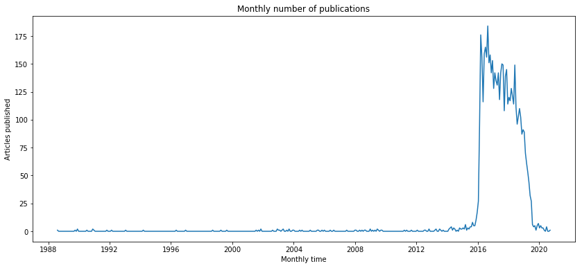

```python
# Number of publications over time
num_articles_time = df_articles.groupby(pd.Grouper(key='date', freq='4W')).count()
fig = plt.gcf()
fig.set_size_inches(14, 6)
p=plt.subplot(111)
plt.plot(num_articles_time["title"])
# Define labels, legends, titles
p.set_xlabel("Monthly time")
p.set_ylabel("Articles published")
p.set_title("Monthly number of publications")
```

**Part 2: Clustering from affiliation information**

The first and main part of the analysis relies on affilaition information. In this section, we want to understand how countries collaborate with each other by writing articles together.

First, we can look at the number of articles published for each continent.

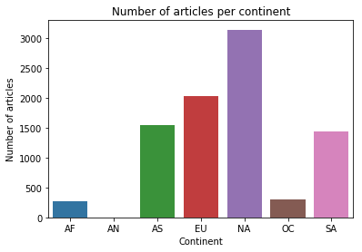

```python
sns.barplot(x="Continent", y="uniq_occur", data=df_countries.groupby("Continent")["uniq_occur"].sum().reset_index())
plt.ylabel('Number of articles')
plt.title('Number of articles per continent')

fig = plt.gcf()
fig.set_size_inches(6, 4)
```

Most of the research is conducted by North America and Europe. South America (the focus of the Zika outbreak) has a decent research output comparable to Asia. Africa and Oceania have very small contributions. In further analsysi this could be compared to other diseases to understand if this research is specific to Zika or not. Now let's take a closer look at specific countries.

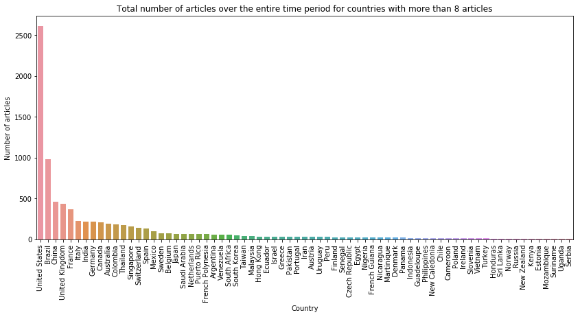

```python
df=df_countries.loc[df_countries["uniq_occur"] > 8].sort_values(by=['uniq_occur'], ascending=False)
ax = sns.barplot(x="Country", y="uniq_occur", data=df)
plt.xticks(rotation=90)
plt.ylabel('Number of articles')
plt.title('Total number of articles over the entire time period for countries with more than 8 articles')

fig = plt.gcf()
fig.set_size_inches(14, 6)
```

The United States publishes the most by far with alamost half of the research in the area. Brazil's second position is interesting. First of all, Brazil is one of the epicenters of the Zika outbreak. It is also the leading research country in latin America. The lack of research before 2016 suggests a strong Brazilian response to the outbreak. Another important Latin American country worth mentioning that also was heavily impacted by the outbreak is Colombia, which stays at the 11th position.

We can focus on selected countries over time. Only the 2016-2010 period is considered as 97% of articles were written on that interval.

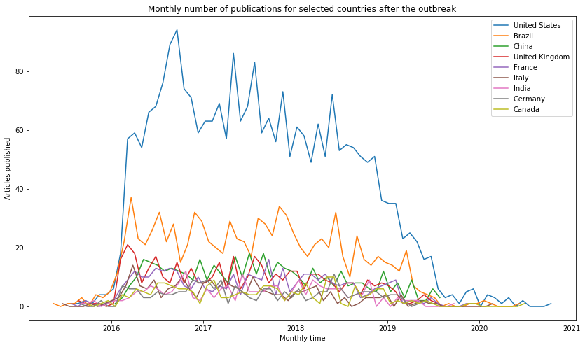

```python
top_countries = df_countries.loc[df_countries["uniq_occur"] > 1].sort_values(by=['uniq_occur'], ascending=False)["Country"]

# Indeces for articles after a certain date
time_indeces=df_articles.loc[df_articles["date"]>datetime(2015,5,1)]["articleID"].values

for top_cont in top_countries[0:9]:
    # Indeces for specific country
    indeces = df_article_countries.loc[df_article_countries["country"] == top_cont]["articleID"].values
    indeces = list(set(time_indeces) & set(indeces))
    x=df_articles.loc[df_articles["articleID"].isin(indeces)].groupby(pd.Grouper(key='date', freq='4W')).count()["title"]

    plt.plot(x)

plt.xlabel("Monthly time")
plt.ylabel("Articles published")
plt.title("Monthly number of publications for selected countries after the outbreak")
plt.legend(top_countries[0:9])

fig = plt.gcf()
fig.set_size_inches(14, 8)
```

Most countries seem to start researching fairly quickly and at the same time around 2016. The U.S. and Brazil do begin a bit earlier in 2015. This coincides with the first cases being detected in Brazil, right after the 2014 World Cup and the 2016 Olympic games. Countries' interest decreases mid-2018 and even disappears for many countries at the end of 2019.

Now that we have some descriptive information, let's focus on collaboration. First we can look at the number of country affiliations per article.

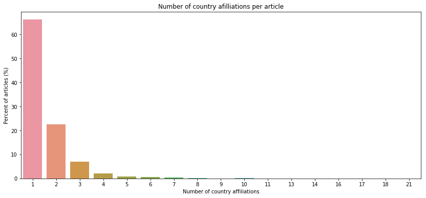

```python
# First group by articleID, count the number of countries within the article.
# We then group by number of countries (bin all articles with 1 country, all articles with 2 countries..) and count them
num_countries_per_art=df_article_countries.groupby(["articleID"]).count().groupby(["country"]).count().reset_index()
# Normalize as percentage
num_countries_per_art["country_mentions"] = num_countries_per_art["country_mentions"] / len(df_articles) * 100
p=sns.barplot(x="country", y = "country_mentions", data=num_countries_per_art)
plt.xlabel('Number of country affiliations')
plt.ylabel('Percent of articles (%)')
plt.title('Number of country afilliations per article')

fig = plt.gcf()
fig.set_size_inches(14, 6)
```

From this, we can see that most articles have a single country affiliation (66%). The rest of the distribution decreases monotonically for the number of affiliations, with up to 21 countries involved in a single article. At this point, it is worth noting the scale at which we are analysing this dataset. The "country" scale was chosen becacuse it is easier to categorize affiliations this way and also represents a good compromise between local efforts and global initiatives. However, within each category, it is important to recognize the inner collaboration within a country at a state, local or intitutional level.

That being said, we can expand this this general trend and apply it to the top countries.

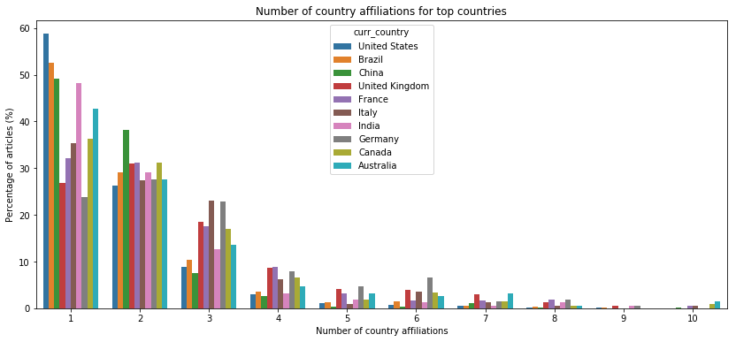

```python
top_countries = df_countries.loc[df_countries["uniq_occur"] > 1].sort_values(by=['uniq_occur'], ascending=False)["Country"]

all_data = pd.DataFrame(columns=["country", "country_mentions", "continent", "curr_country"])
for top_cont in top_countries[0:10]:
    # Indeces for specific country
    indeces = df_article_countries.loc[df_article_countries["country"] == top_cont]["articleID"].values
    # Make counts for number of countries shared by article
    df=df_article_countries.loc[df_article_countries["articleID"].isin(indeces)].groupby("articleID").count().groupby(["country"]).count().reset_index()
    # Get total number of articles
    total_articles = df["country_mentions"].sum()
    # Normalize as percentage
    df["country_mentions"]=df["country_mentions"]/total_articles*100
    # Add current country
    df["curr_country"] = top_cont
    # Add data to overall table
    all_data=pd.concat([all_data, df[0:9]])

# Plot
sns.barplot(x="country", y = "country_mentions", data=all_data, hue="curr_country")


plt.xlabel("Number of country affiliations")
plt.ylabel("Percentage of articles (%)")
plt.title("Number of country affiliations for top countries")

fig = plt.gcf()
fig.set_size_inches(14, 6)
```

The United States and Brazil are the only countries among the top 10 that have more than 50% of their research being conducted without external collaboration. There seems to be a correlation between total number of articles pusblished and number of country collaborators.

On the other side, European countries such as the UK, Germany and France have the lowest, individually conducted reseach suggesting higher collaboration. These 3 countries have more than 65% of their research shared by other countries.

We can plot the total number of articles written by a country (x-axis) versus the number of articles written with i other countries affiliated. We should expect a linear relationship between these two. However, deviations from the model will suggest higher or lower collaboration rates with other countries.

```
Model: number articles shared with i collaborators ~ total number of articles
Residual = y_real - y_model

Countries with residuals > 1.5 standard deviations (32.0) for 1 country affiliations
           Country  uniq_occur country_mentions    resid
0    United States        2610             1534  64.7518
3   United Kingdom         436              117 -118.376
4           France         371              119 -79.4843
5            Italy         226               80 -36.1883
7          Germany         214               51 -58.3776
11        Thailand         179               56  -33.513
13     Switzerland         144               31 -38.6485


Countries with residuals > 1.5 standard deviations (12.0) for 2 country affiliations
           Country  uniq_occur country_mentions    resid
0    United States        2610              683 -23.0418
1           Brazil         979              285  18.8067
2            China         460              176  49.7707
3   United Kingdom         436              135  15.2431
4           France         371              116  13.7723
11        Thailand         179               90  39.5509


Countries with residuals > 1.5 standard deviations (11.0) for 3 country affiliations
           Country  uniq_occur country_mentions    resid
0    United States        2610              230 -17.6631
2            China         460               35 -11.4949
3   United Kingdom         436               81  36.7507
4           France         371               65  26.8325
5            Italy         226               52  27.3997
7          Germany         214               49  25.5225
8           Canada         212               36  12.7096
13     Switzerland         144               34  17.0721
19    Saudi Arabia          68               23  13.1832


Countries with residuals > 1.5 standard deviations (6.0) for 4 country affiliations
           Country  uniq_occur country_mentions    resid
0    United States        2610               80 -6.92108
3   United Kingdom         436               38   21.344
4           France         371               33  18.4448
7          Germany         214               17  7.51913
13     Switzerland         144               17  9.78158
```

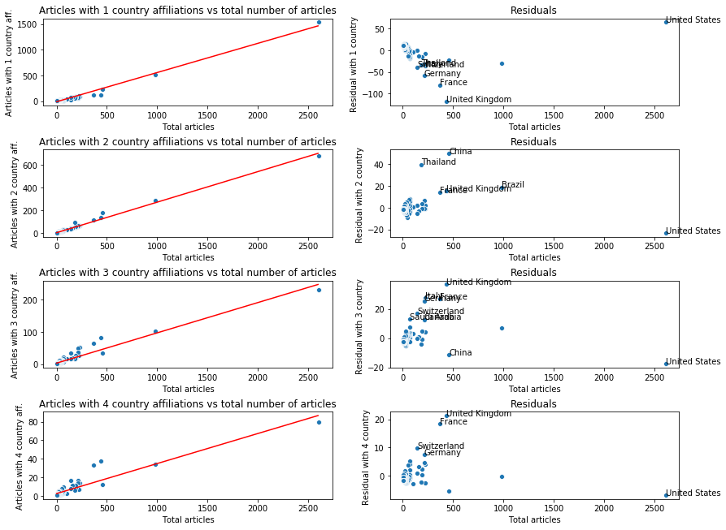

```python
all_data = pd.DataFrame(columns=["country", "country_mentions", "continent", "curr_country"])
for top_cont in top_countries:
    # Indeces for specific country
    indeces = df_article_countries.loc[df_article_countries["country"] == top_cont]["articleID"].values
    # Make counts for number of countries shared by article
    df=df_article_countries.loc[df_article_countries["articleID"].isin(indeces)].groupby("articleID").count().groupby(["country"]).count().reset_index()
    # Get total number of articles
    total_articles = df["country_mentions"].sum()
    # Normalize as percentage
    df["country_mentions"]=df["country_mentions"]
    # Add current country
    df["curr_country"] = top_cont
    # Add data to overall table
    all_data=pd.concat([all_data, df[0:9]])

print("Model: number articles shared with i collaborators ~ total number of articles")
print("Residual = y_real - y_model", "\n")

for i in [1,2,3,4]:
    plt.subplot(8,2,i*2-1)
    df=df_countries.sort_values(by=['uniq_occur'], ascending=False)[["uniq_occur", "Country"]]
    df=df.merge(all_data.loc[all_data["country"]==i], left_on="Country", right_on="curr_country")

    # Plot data and fitted model
    sns.scatterplot(x="uniq_occur", y="country_mentions", data=df, legend=False)
    fit_coef = np.polyfit(df["uniq_occur"].values, df["country_mentions"].values.astype(np.int64), 1)
    x_fit = np.linspace(0, 2600, 100)
    y_fit = np.poly1d(fit_coef)(x_fit)
    plt.plot(x_fit,y_fit, 'r-')
    plt.xlabel("Total articles")
    plt.ylabel("Articles with {} country aff.".format(i))
    plt.title("Articles with {} country affiliations vs total number of articles".format(i))


    # Get residuals, exceptions
    df["resid"] = df["country_mentions"] - np.poly1d(fit_coef)(df["uniq_occur"])
    exceptions=df.loc[np.abs(df["resid"]) > df["resid"].std() * 1.5]
    print("Countries with residuals > 1.5 standard deviations ({}) for {} country affiliations".format(round(df["resid"].std() * 1.5), i))
    print(exceptions[["Country", "uniq_occur", "country_mentions", "resid"]], "\n\n")

    # Plot residuals
    plt.subplot(8,2,i*2)
    sns.scatterplot(x="uniq_occur", y="resid", data=df, legend=False)
    plt.subplots_adjust(top = 1.2, hspace = 0.5)
    plt.xlabel("Total articles")
    plt.ylabel("Residual with {} country ".format(i))
    plt.title("Residuals")

    # Add labels to exceptions on residuals
    for j in range(0,len(exceptions["uniq_occur"])):
        plt.text(exceptions["uniq_occur"].values[j], exceptions["resid"].values[j], exceptions["Country"].values[j])


fig = plt.gcf()
fig.set_size_inches(14, 16)
```

The residual sign changes as expected for 2,3,4-affiliation in the articles. Indeed, The U.S now produces less shared articles in all those categories than most of the other European countries. Overall, European countries have the tendency to produce more collaborative articles as previously expected.

We can abstract out the countries into continents:

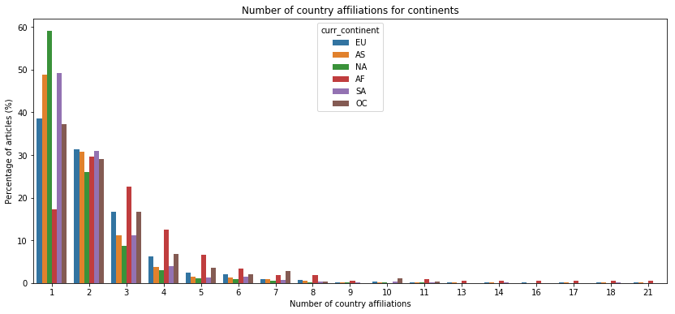

```python
continents = df_countries["Continent"].unique()

all_data = pd.DataFrame(columns=["continent", "country", "country_mentions", "curr_continent"])
for top_cont in continents:
    # Indeces for specific continent
    indeces = df_article_countries.loc[df_article_countries["continent"] == top_cont]["articleID"].values
    # Make counts for number of countries shared by article
    df=df_article_countries.loc[df_article_countries["articleID"].isin(indeces)].groupby("articleID").count().groupby(["continent"]).count().reset_index()
    # Get total number of articles
    total_articles = df["country_mentions"].sum()
    # Normalize as percentage
    df["country_mentions"]=df["country_mentions"]/total_articles*100
    # Add current country
    df["curr_continent"] = top_cont
    # Add data to overall table
    all_data=pd.concat([all_data, df])

# Plot
sns.barplot(x="continent", y = "country_mentions", data=all_data, hue="curr_continent")


plt.xlabel("Number of country affiliations")
plt.ylabel("Percentage of articles (%)")
plt.title("Number of country affiliations for continents")

fig = plt.gcf()
fig.set_size_inches(14, 6)
```

This graph suggests very high degrees of collaboration among African countries. Although richer continents have the tendency to research on their own more often, it is worth noting that European countries still have higher degrees of collaboration. It is possible that European and African countries work together on projects. This association is harder to extract from plots like this. A graph showing the complex network will be more useful to assess the collaboration patterns.

**Graph representation**

Now that we have an idea about what countries collaborate the most, we want to understand who they actually work with. In order to do create a graphical representation of collaboration, we will start by making a bipartite graph. One set of nodes will contain countries and the other set of nodes will represent articles. In order to create edges, unique affiliations will be considered. For example let's say article A has 3 authors from the U.S., 2 authors from France and 1 from Brazil. Therefore, an node A wil be connected to the U.S, France and Brazil, with a weight of 1 for each. The multiplicity of authors from a same country for a given article is therefore discarded. This weighing method is chosen to reduce saturation effects.

```python
# Create graph
g = nx.Graph()

# Get countries with at least one article, add nodes to graph
countries = df_countries.loc[df_countries["uniq_occur"] > 0]["Country"]
for country in countries:
    g.add_node(country)
    n = g.node[country]
    n["Maincountry"] = True
    n["start_time"] = "1967/01/01"
    n["end_time"] = "2021/01/01"
    n["end_time_int"] = "2021/01/01"

# Loop through articles, add them to the graph
articleIDs = df_article_countries["articleID"]
for id_a in articleIDs.unique():
    g.add_node(id_a)
    n = g.node[id_a]
    n["Maincountry"] = False
    date = df_articles.loc[df_articles["articleID"] == id_a]["date"].values[0]
    n["start_time"] = date.strftime('%Y/%m/%d')
    n["end_time_int"] = (date + timedelta(weeks=8)).strftime('%Y/%m/%d')
    n["end_time"] = "2021/01/01"

# Connect articles to the countries they are affiliated to
countries = df_article_countries["country"]
for a_id,country in zip(articleIDs, countries):
    g.add_edge(a_id, country)

# Save graph file to export to another visualization program (gephi)
nx.write_gexf(g, "zika_2.gexf")
```

This builds a bipartite graph with nodes being either countries (green) or articles (pink). Labels and node size are proportional to the node degree. Only countries with more than 11 articles are being labeled for clarity reasons in the graph. All other countries are still displayed without the label.

[figure not shown]

We can also perform a community detection algorithm. A resolution of 2.2 was chosen to obtain 6 clusters.

This was achieved through Gephi, by using the algorithm described by:

*Vincent D Blondel, Jean-Loup Guillaume, Renaud Lambiotte, Etienne Lefebvre, Fast unfolding of communities in large networks, in Journal of Statistical Mechanics: Theory and Experiment 2008 (10), P1000*

[figure not shown]

From visual inspection, communities seem to overlap with grographical information. For example, most European countries work together as a tight community (light blue). South american countries tend to work together as well as Spain (dark blue). This is likely due to same use of language (Spanish). Asian countries have a more disperesed collaboration with no clear, tight communities. China, Thailand, Hong Kong and South Korea share a community (brown) while India, Pakistan, Malaysia, are in another (pink).

These communities show once again the strong collaboration in European countries, compared to all other regions. There is also the inclusion of some African countries and old French colonies in that cluster which closely collaborate with European partners. However, decomposing the clusters into different connected components can be misleading. For example, Brazil and the United States do have a very large number of shared articles. However, this strong association is not clear from the individual connected components as they are in different clusters.

It is necessary to focus on a limited subset of countries to obain more in depth collaboration metrics.

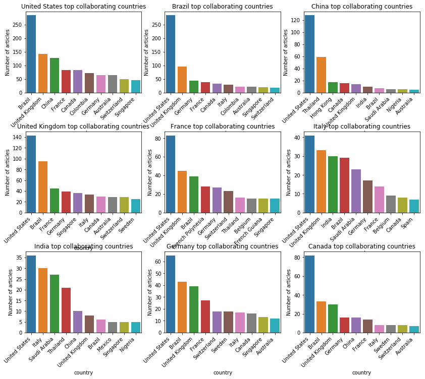

```python
# Find top countries
top_countries = df_countries.loc[df_countries["uniq_occur"] > 1].sort_values(by=['uniq_occur'], ascending=False)["Country"]

# Create figure
fig = plt.gcf()
fig.set_size_inches(14, 6)

# Loop through top countries, find collaborating partners
for i,top_cont in enumerate(top_countries[0:9]):
    # Find the articleIDs that match a specific country
    indeces = df_article_countries.loc[df_article_countries["country"] == top_cont]["articleID"].values
    # Select articles that have the IDs for the specific country, groupby countries that collaborate
    # count them.
    df=df_article_countries[df_article_countries["articleID"].isin(indeces)].groupby("country").count().reset_index()[["country", "country_mentions"]]
    # Remove the country itself as we only want collaborating countries
    df = df[df.country != top_cont]
    # Sort and select top 10
    df = df.sort_values(by=['country_mentions'], ascending=False)[0:10]
    # Plot
    plt.subplot(3,3,i+1)
    ax = sns.barplot(x="country", y="country_mentions", data=df)

    plt.xticks(rotation=45, ha="right")
    ax.set_ylabel('Number of articles')
    plt.title('{} top collaborating countries'.format(top_cont))
    plt.subplots_adjust(top = 1.6, hspace = 0.48)
```

A striking partnership in these graphs is between India and Italy. Italy would be expected to have more European partners and not such a strong collaboration with India. The language barriers and lack of historical connection make this associaton worth investigating in the future. The same goes for the Italy-Saudi Arabia partnership. A manual data inspection through the affiliation recogntition algorithm should also be necessary.

Describing collaboration for each country in this way allows us to expand the model. We can create a projection of the bipartite graph from this information that only contains country nodes and abstracts away the article nodes.

In order to do this, we will have a weight between country pairs that represents the number of articles in which both countries appear.

```python
# Find top countries
top_countries = df_countries.loc[df_countries["uniq_occur"] > 0].sort_values(by=['uniq_occur'], ascending=False)["Country"]

# Create graph
g = nx.Graph()

# Get countries with at least one article, add nodes to graph
countries = df_countries.loc[df_countries["uniq_occur"] > 0]["Country"]
for country in top_countries:
    g.add_node(country)
    n = g.node[country]

# Loop through top countries, find collaborating partners
for i,top_cont in enumerate(top_countries):
    # Find the articleIDs that match a specific country
    indeces = df_article_countries.loc[df_article_countries["country"] == top_cont]["articleID"].values
    # Select articles that have the IDs for the specific country, groupby countries that collaborate
    # count them.
    df=df_article_countries[df_article_countries["articleID"].isin(indeces)].groupby("country").count().reset_index()[["country", "country_mentions"]]
    # Remove the country itself as we only want collaborating countries
    df = df[df.country != top_cont]
    # Sort and select top 10
    df = df.sort_values(by=['country_mentions'], ascending=False)[0:10]
    for country, mentions in zip(df["country"], df["country_mentions"]):
        g.add_edge(country, top_cont, weight=mentions)


# Save graph file to export to another visualization program (gephi)
nx.write_gexf(g, "zika_projection.gexf")
```

Applying the same cluster detection algorithm desribed above, we can detect country communities in this projection graph.

[figure not shown]

This projection might suffer from a bias towards large country researchers inducing large clusters around them and decreasing the importance of smaller clusters. However, a striking cluster is found in green with many Eastern European countries, north African countries (Maghreb) and Middle East countries in a very distinct and tight collaboration network, independent from West European influences. Underdtanding this association from other sources and policies could be very interesting.

We can also import data generated by Gephi and the graph. More specifically, we can import the clusters detected from the projection graph as the "modularity_class" variable.

```python
# Import from csv file
df_all = pd.read_csv("zika_projection.csv", sep=',')

# Extract clusters from projection graph
df_countries=df_countries.merge(df_all[["id", "modularity_class"]], left_on="Country", right_on="id").drop("id", axis=1)
df_countries.head(5)
```

|  | Code | Country | Population | Continent | total_occur | uniq_occur | modularity_class |
| --- | --- | --- | --- | --- | --- | --- | --- |
| 0 | AL | Albania | 2986952 | EU | 20 | 6 | 4 |
| 1 | AM | Armenia | 2968000 | AS | 6 | 4 | 4 |
| 2 | AR | Argentina | 41343201 | SA | 174 | 59 | 0 |
| 3 | AS | American Samoa | 57881 | OC | 3 | 2 | 0 |
| 4 | AT | Austria | 8205000 | EU | 120 | 30 | 1 |

Now that we have extracted the clusters from the projection graph, we can explore the relationships.

First, we can see if there are continental associations related to the colaboration clustering.

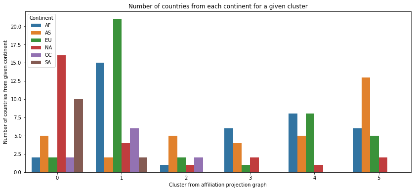

```python
df=df_countries.groupby(["modularity_class", "Continent"]).count().reset_index()[["modularity_class", "Continent", "Code"]]

# Plot
sns.barplot(x="modularity_class", y = "Code", data=df, hue="Continent")


plt.xlabel("Cluster from affiliation projection graph")
plt.ylabel("Number of countries from given continent")
plt.title("Number of countries from each continent for a given cluster")

fig = plt.gcf()
fig.set_size_inches(14, 6)
```

Cluster 0 mainly contains countries from South America and North America. Cluster 1 mainly has European and African countries. African research seems to be highly linked to European research. From the graph this makes sense as we could observe a high collaboration between France and French-speaking countries in Africa. These two clusters seem to be the highest regional partners in terms of Zika research with the other clusters displaying higher degrees of continental variance.

**Part 3: Clustering from abstract information**

From the article affiliations, we have been able to cluster countries and create the collaboration graph. We now want to take advantage of the abstract and keyword information for each document. The abstract can give us an idea on the topics covered and research interests of the article.

However, due to the limited scope and time frame of this assignment and the complexity of the abstract information, we will focus on the keyword information which displays lower levels of noise and variance that require less complex NLP methods and topic-specifc knowledge in the research area. It is worth noting that keywords are missing in many articles as mentioned in the first part of the analysis and might not completly represent the entire dataset (about 50% of articles provide keywords). This again would be solved by using abstract and full document information in a future, more through analysis.

```python
# Get abstract data for the articles
corpus=df_articles["all_keywords"].values # for an abstract analysis, simply replace "all_keywords" with "abstract"
corpus_ids = df_articles["articleID"].values
```

This simple NLP analysis uses a Snowball stemming in order to more easily capture very similar words into single entities. Punctuation is also removed.

Once the words are preprocessed, we calculate the tf-idf of the entire corpus. Ths step basically gives a weight to each word based onits frequency within a document whiile giving less weight to very common words that appear in many documents and therefore yield very low levels of information gain.

The tf-idf for the corpus serves to create an encoder that transforms documents into feature vectors. These vectors now define or serve as the signature of the document.

```python
# Preprocess data (remove punctuation, numbers, put lowercase)
translator = str.maketrans('', '', string.punctuation)
corpus = [re.sub(r"\d", "", s.lower().translate(translator)) for s in corpus]

stemmer = SnowballStemmer('english')

def stem_tokens(tokens):
    stemmed_tokens = []
    for token in tokens:
        stemmed_tokens.append(stemmer.stem(token))
    return stemmed_tokens

def tokenize(doc):
    tokens = nltk.word_tokenize(doc)
    stemmed_tokens = stem_tokens(tokens)
    return stemmed_tokens


# Calculate tf-idf
vectorizer = TfidfVectorizer(tokenizer=tokenize)
tfs = vectorizer.fit(corpus)
feature_names = vectorizer.get_feature_names()


# Write the vectors to a csv first as this is much faster than loading them one by one to
# a pandas table
with open("temp.csv", "w", newline='', encoding='utf-8') as f:
    wr = csv.writer(f, delimiter=",")
    wr.writerow(["articleID"] + feature_names)
    for i, (doc,id_) in enumerate(zip(corpus,corpus_ids)):
        # i and id_ are most liekly the same (but if in future code changes rows are dropped and IDs are not continuous
        # it is better to have a robust link to the articleIDs
        vector = [id_] + list(vectorizer.transform([doc]).toarray()[0])
        wr.writerow(vector)

# Create table to store the feature vectors for all documents from csv
abstract_vectors = pd.read_csv("temp.csv")


# Transform pandas table into numpy array for kmeans. We ignore the articleID column
dataset_array = abstract_vectors.loc[:, abstract_vectors.columns != 'articleID'].values
```

Now that each **article** has a feature vector (from the keywords), we can use k-means to cluster articles together. An individual article now has a cluster number assigned. We use k-means because it is a simple unsupervised machine learning algorithm (we don't have labels). Although the choice of 6 clusters is arbitrary, some experimentation with other k numbers were tested and yielded worse results. However, a more systematic way of testing the ideal k value should be implemented in the future.

```python
# Cluster feature vectors
NUM_CLUSTERS = 6
kmeans = KMeans(n_clusters=NUM_CLUSTERS, random_state=0).fit(dataset_array)
df_articles["kmeans_cluster"] = kmeans.predict(dataset_array)
```

Let's go through the clusters and display the top keywords. Note that we are displaying a table that was manually created from these keywords with the given code. This manual intervention is necessary to evaluate the clusters and attempt to assign some "meaning" or global key term to each cluster.

```python
for i in range(0, NUM_CLUSTERS):
    ids=df_articles.loc[df_articles["kmeans_cluster"]==i]["articleID"].values
    df=abstract_vectors.loc[abstract_vectors["articleID"].isin(ids)].sum().sort_values(ascending=False).head(21)
    #print("Cluster = {}\n".format(i), df[1:], "\n") # print top keywords, remove first one (articleID..)
```

[figure not shown]

For each column, important keywords (bold) were used to get a general sense of the cluster (last row). This more subjective human work is essential and requires some specific knowledge in the area. Further collaboration with scientists could help improve the categorization of these keywords.

The third cluster is the only that mentions specific geographical regions, travel and public health issues related to outbreak management.

The fourth cluster emphasizes neurological and nervous system effects and diseases such as Guillain-Barre and microencephalia. These are related in practice to pregnant women and fetal syndromes, both of which appear as keywords as well.

The fifth cluster highlights transmission vectors and infection related terms such as mosquito species (Culex, Aed for Aedes Aegypty) as well as mosquito-specific bacteria (Wolbachia). Insecticids and control are also reported, which relate to mosquito control methods.

The last cluster exhibits more heterogenous behavior. However, there is some emphasis on immunological terms such as antivirus, antibodies, immunology, viral, infection and vaccine.

After clustering **articles** we can group the documents by country to investigate new trends. We can expand this analysis by grouping the features for all countries. Indeed, we can define a new feature vector for each country as a histogram for each country containing the cluster distribution of its articles. Once each country has a feature vector, we can cluster again the **countries** to detemine country similarities and potential research focus similarities.

```python
def get_country_vec(data):
    f = np.arange(0.0, NUM_CLUSTERS)
    for i in range(0,NUM_CLUSTERS):
        num=data.loc[data["kmeans_cluster"]==i]["title"].values
        f[i] = num[0] if len(num) > 0 else 0
    return f
```

```python
# Get top countries (in terms of number of articles)
top_countries = df_countries.sort_values(by=['uniq_occur'], ascending=False)["Country"]

# Table to save feature vector for each country
all_data = pd.DataFrame(columns=np.arange(0,NUM_CLUSTERS))

# Loop through contries, find articles for the country and count (bin) each cluster
for i,top_cont in enumerate(top_countries):
    # Get indeces for country
    indeces = df_article_countries.loc[df_article_countries["country"] == top_cont]["articleID"].values
    # Get data, bin
    data=df_articles.loc[df_articles["articleID"].isin(indeces)].groupby(["kmeans_cluster"]).count().reset_index()[["kmeans_cluster", "title"]]
    # Normalize to percentage
    data["title"] = data["title"] / data["title"].sum()
    # Get vector
    f=get_country_vec(data)
    # Save to table
    all_data.loc[i] = f


dataset_array = all_data.values
```

We run kmeans again to cluster countries. We choose 6 again to matchthe initial affiliation cluster number but further work needs to be done to systematically define this variable.

```python
# Cluster feature vectors from countries
NUM_CLUSTERS_2 = 6
kmeans = KMeans(n_clusters=NUM_CLUSTERS_2, random_state=0).fit(dataset_array)
df_countries["kmeans_country_cluster_tfidf"] = kmeans.predict(dataset_array)
```

We can take a look at the different clusters one by one as a supercial inspection.

Here we display the top countries (measured by number of articles for the country) for each cluster.

Note: These clusters do not correspond to the clusters previously mentioned with main research themes. That linking part and cluster comparison will have to be expanded in the future!

```python
vars_ = ["Country", "Continent", "uniq_occur","modularity_class"]

for i in range(0,NUM_CLUSTERS_2):
    cond=(df_countries["kmeans_country_cluster_tfidf"]==i) & (df_countries["uniq_occur"]>0)
    df=df_countries.loc[cond].sort_values(by="uniq_occur", ascending=False)[vars_].head(6)
    print("Cluster:", i, "\n", df, "\n")
```

```
Cluster: 0
             Country Continent  uniq_occur  modularity_class
151   United States        NA        2610                 0
51   United Kingdom        EU         436                 1
71            Italy        EU         226                 5
141        Thailand        AS         179                 3
133       Singapore        AS         159                 1
132          Sweden        EU          72                 1

Cluster: 1
        Country Continent  uniq_occur  modularity_class
102     Mexico        NA         102                 0
122   Portugal        EU          31                 1
108  Nicaragua        NA          22                 0
119     Poland        EU          14                 1
155    Vietnam        AS          12                 2
150     Uganda        AF           9                 3

Cluster: 2
     Country Continent  uniq_occur  modularity_class
16   Brazil        SA         979                 0
29    China        AS         460                 3
49   France        EU         371                 1
68    India        AS         220                 5
37  Germany        EU         214                 1
20   Canada        NA         212                 0

Cluster: 3
            Country Continent  uniq_occur  modularity_class
5        Australia        OC         192                 2
41         Ecuador        SA          33                 0
118       Pakistan        AS          31                 5
70            Iran        AS          30                 5
46         Finland        EU          28                 1
54   French Guiana        SA          23                 1

Cluster: 4
             Country Continent  uniq_occur  modularity_class
109     Netherlands        EU          67                 1
115            Peru        SA          29                 0
36   Czech Republic        EU          25                 5
107         Nigeria        AF          24                 3
112     New Zealand        OC          11                 2
111           Nepal        AS           4                 5

Cluster: 5
               Country Continent  uniq_occur  modularity_class
116  French Polynesia        OC          66                 1
120       Puerto Rico        NA          66                 0
147            Taiwan        AS          43                 5
134          Slovenia        EU          13                 5
145            Turkey        AS          12                 4
127            Serbia        EU           9                 4
```

This result is difficult to evaluate and interpret. As the main theme determination is manually done after eachclustering run, there is no systematic way of matching these clusters to the main theme. In the future, the goal would be to assign to these groups of countries, a main theme that is being researched or a distribution of themes to undertsand countries' research priorities.

We will go back to the document feature vectors and forget about countries for a moment. Let's remember that we calculated the entire similarity matrix between each article (that has keywords). We could use this as weights between nodes in a graph. However, as we care about clustering countries from the articles and not the articles themselves, we will create a new projection of the bipartite graph to the country set.

In other words, we will loop through each pair of articles (n choose 2) and extract the country affiliations for each pair. Then, we will link countries from both articles in the pair and assign a weight defined by the similarity between the articles divided (normalized) by the total number of country affiliations. This normalization or hyperbolic normalization is commonly used in projections of this type to avoid saturation efffects. By saturation, we mean that there are diminishing returns if an article has 22 affiliations and thus the actual collaboration between countries might be reduced as it is deemed more superficial.

Now to the actual code. We first sample 500 points (articles) which have keywords (we don't want to sample articles that don't even have a keayword list!).

```python
# We only want to sample 500 aticles from the article that do have keywords

# Find indeces of articles with keywords
indeces=df_articles.loc[df_articles["all_keywords"]!=""]["articleID"].sample(n=500).values

# Get those articles
df=abstract_vectors.loc[abstract_vectors["articleID"].isin(indeces)]

# Recalculate indeces because isin() suffles them and we do care aboutthe final df articleID order
indeces = df["articleID"].values

# Remove articleID column from df
df=df.loc[:, df.columns != 'articleID']

# Calculate similarity between vectors, get matrix
similarity_matrix=cosine_similarity(df)
```

Now, the actual graph construction.

```python
# Create graph
g = nx.Graph()

# Get countries with at least one article, add nodes to graph
countries = df_countries.loc[df_countries["uniq_occur"] > 0]["Country"]
for country in countries:
    g.add_node(country)
    n = g.node[country]
    n["Maincountry"] = True
    n["start_time"] = "1967/01/01"
    n["end_time"] = "2021/01/01"
    n["end_time_int"] = "2021/01/01"

num_articles = len(similarity_matrix)

# Loop through all articles that we selected (that have keywords)
for i in range(0, num_articles):

    # Get i articleID
    id_i = indeces[i]
    # Get countries from article i
    countries_i = df_article_countries[df_article_countries["articleID"]==id_i]["country"].values

    for j in range(i+1,num_articles):
        # Get j articleID
        id_j = indeces[j]
        # Get countries from article j
        countries_j = df_article_countries[df_article_countries["articleID"]==id_j]["country"].values

        # Num countries between both article affiliations to normalize
        num_countries = len(np.unique(np.concatenate((countries_i, countries_j))))

        # Get similarity between articles i and j, use as weight and use hyperbolic normalization
        weight_ij = similarity_matrix[i][j] / num_countries

        # Connect nodes
        for c1 in countries_i:
            for c2 in countries_j:
                if c1 != c2:
                    w = g.get_edge_data(c1,c2, default={"weight":0})["weight"]
                    g.add_edge(c1, c2, weight= w + weight_ij)


nx.write_gexf(g, "zika_tfidf.gexf")
```

[figure not shown]

The resulting graph is very messy. The clusters are not as marked as the ones observed in the affiliation graph. An important point to highlight is the large purple cluster that dominates the graph. This could be the result from a bias induced by the fact that even though countries that publish more articles might specialize in certain topics, their non-priority topics still exceed by number the publication numbers of small countries. In other words and with a made up example, let's say the U.S highly specilizes in drug development and the Dominican Republic highly specializes in mosquito control methods. However, if the US does collaborate (by affiliation) with the Dominican Republic, and given that a small percentage of American research in mosquito control still outnumber all of Dominican research, then both countries will appear in the same cluster. The U.S. will englobe the Dominican Republic even though the research focus are differents. Normlization techniques including total number of publications by country could be used in the future in order to counter this type of bias and obtain more meaningful topic-clusters and graphs. Note: the thickness of the edges is not proportional and was scaled down more aggresively for very large weights (for example the Brazil-U.S. weight) as it made the graph unreadable.

**Conclusion**

The affiliation analysis yields good results with strong independent communities that share certain geographical, economic and historical ties. A strong European collaboration was found for both internal (between other European countries) and itra levels (with countries from other geographical, mainly Africa). The United States is a leading researcher in the topic but displays lower than expected levels of collaboration with other countries. The strongest ties of the United States are found in latin America, largely due to Brazil's massive contribution to the topic. This strong Brazilian contibution alligns well with its owns needs as it was the epicenter of the 2015-2016 outbreak. The content (abstract and keyword) clustering part has mixed results. From one side, the clustering methods for individual articles yields coherent results with strong themes which can be recognized by humans with a basic understanding of biological and public health research. However, more work needs to be done to map these themes to actual country clusters in a reliable and robust manner. Additionally, full text documents (instead of just the abstract and keywords) and more complex NKP algorithm should be applied to handle the subtleties in research themes. The final point to improve in this analysis is the matching between the article information and research being conducted with the actual guidelines, agendas and policies as determined by institutions such as the World Health Organization (WHO), the PanAmerican Health Organization (PAHO) among others.